# Financial Ratio and Stock Growth Presentation

Tej Patel

## Research Question and Goal

Research Question: Are companies with lower price-to-earnings (P/E) ratios more likely to have higher stock price growth?

Goal: Using the Price-to-Earnings Ratio from 2020 data from Kaggle, we can compare the five-year return value of stocks from 2020 up to 2025 to see if the lower P/E ratio did cause a higher return value of stocks over the past five years.

## Varaibles and Table

Indepedent Variable: Price-to-Earnings Ration

Dependent Variable: Five-Year Return value from Stocks

Top 10 Rows:

[output not shown]

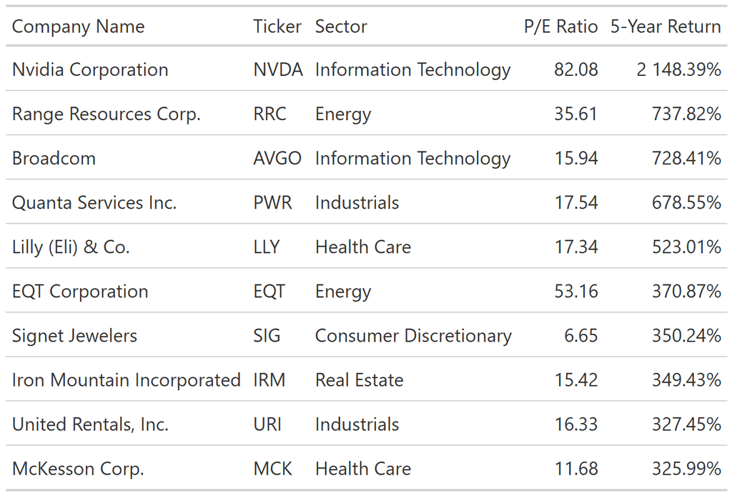

## Hypothesis

Null Hypothesis (H₀): There is no relationship between the Price-to-Earnings (P/E) ratio and 5-year stock return. (P/E ratio does not predict future stock growth.)

Alternative Hypothesis (H₁): There is a negative relationship between the Price-to-Earnings (P/E) ratio and 5-year stock return. (Lower P/E ratios are associated with higher future stock growth.)

In hypothesis testing, to reject the null hypothesis, the p-value must be less than your significance level (α). (α = 0.05)

## Scatterplot

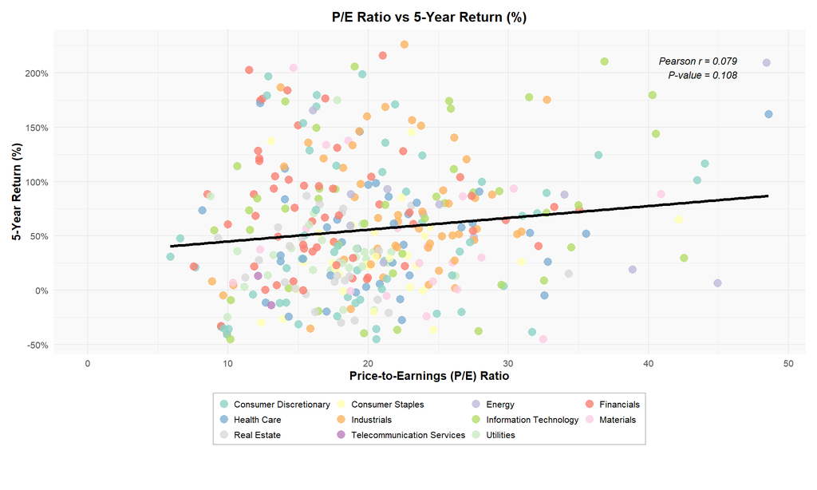

Sources: S&P 500 Companies with Financial Information from Kaggle.

Yahoo Finance using tidyquant and quantmod